# QUEFTS

Gerard H Ros

2025-12-19

## QUEFTS

In 1990 Janssen et al. published the article `A system for quantitative evaluation of the fertility of tropical soils (QUEFTS)`. QUEFTS is a simple method to assess the impact of nitrogen, phosphorus and potassium inputs on crop yield, being developed for tropical soils. The system is applicable to well drained, deep soils, that have a pH(H20) in the range 4.5-7.0, and values for organic carbon, P-Olsen and exchangeable potassium below 70 g/kg, 30 mg/kg and 30 mmol/kg, respectively (0-20 cm). Soil fertility is interpreted as the capacity of a soil to provide plants with nitrogen, phosphorus and potassium, but the methodology allows for including other nutrients.

The procedure consists of four successive steps. First the potential supplies of nitrogen, phosphorus and potassium are calculated, applying relationships between chemical properties of the 0-20 cm soil layer and the maximum quantity of those nutrients that can be taken up by maize, if no other nutrients and no other growth factors are yield-limiting. In the second step the actual uptake of each nutrient is calculated as a function of the potential supply of that nutrient, taking into account the potential supplies of the other two nutrients. Step 3 comprises the establishment of three yield ranges, as depending on the actual uptakes of nitrogen, phosphorus, and potassium, respectively. Next, these yield ranges are combined in pairs, and the yields estimated for pairs of nutrients are averaged to obtain an ultimate yield estimate (step 4).

This vignette describes the model implementation of QUEFTS in R to support the MSc thesis work from Wen Rui.

Lets first start with loading the required R packages, needed to do the simulations. We subsequently make a virtual example for a maize crop growing on a free draining sandy soil with the following properties: pH 5.3, P-Olsen 15 mg P/kg, SOC of 35 g /kg, and exchangeable potassium is 25 mmol/kg. The N, P and K dose applied is 55 kg N, 25 kg P and 40 kg K / ha.

```r
  # define all input variables
   soc = 35 # in g/kg
   pol = 15 # in mg P/kg
   kexch = 25 # in mmol/kg
   phw = 5.3 # no unit, pH measured in water
   nfert = 55 # kg N /ha
   pfert = 25 # kg P /ha
   kfert = 40 # kg K /ha

   # set maximum yield (kg /ha)
   max_yield = 16000

  # combine all inputs in one data.table
  dt <- data.table(id = 1,
                   soc = soc,
                   pols = pol,
                   kexch = kexch,
                   phw = phw,
                   nfert = nfert,
                   pfert = pfert,
                   kfert = kfert)

  # show the example
  print(dt)
```

```
##       id   soc  pols kexch   phw nfert pfert kfert
##    <num> <num> <num> <num> <num> <num> <num> <num>
## 1:     1    35    15    25   5.3    55    25    40
```

## Checking inputs

Lets first do some checks on the inputs. This is important since the model output will be useless when the input is incorrect or when input values exceeds the acceptable input ranges for which QUEFTS has been calibrated. Below we use the `checkmate` package, that checks the values of each argument, and when it exceeds the acceptable range, then it generates a warning. If the values are ok, then the code runs smoothly, and no warning is generated.

```r
  # check input lenght to ensure that all variables have the same length
  arg.length <- max(length(nfert),length(pfert),length(kfert),length(soc),length(pol),length(kexch),length(phw))

  # check input of fertilizer inputs
  checkmate::assert_numeric (nfert,lower=0,upper = 500,len = arg.length)
  checkmate::assert_numeric(pfert,lower=0,upper = 500,len = arg.length)
  checkmate::assert_numeric(kfert,lower=0,upper = 800,len = arg.length)

  # check input of the soil properties
  checkmate::assert_numeric(pol,lower=0,upper = 100,len = arg.length)
  checkmate::assert_numeric(soc,lower=0,upper = 200,len = arg.length)
  checkmate::assert_numeric(phw,lower=3,upper = 8,len = arg.length)
  checkmate::assert_numeric(kexch,lower=0,upper = 150,len = arg.length)
```

## Step 1. Calculate the soil supply of N, P and K

The empirical equations to estimate the soil nutrient supply are given below. The potential supply of each of the nutrients nitrogen, phosphorus, and potassium proved related to pH but in different ways. This is expressed in the correction factors fN, fP and fK. For convenience the coefficients were chosen in such a way that fN, fP and fK have values between 0 and 1, and for pH (H20) ranging from 4.5 to 7. The potential supply of nitrogen increases with increasing pH, corresponding with an increase in mineralization rate. From these equations it follows that the supply of nitrogen per growing season equals 2.72, 2.04, and 1.36% of total organic nitrogen in the topsoil (0-20 cm), at pH(H20) values of 7, 6, and 5, respectively.

The expression for fP is parabolic, showing an optimum at pH 6 and zero values for pH 4.6 and 7.4.Between pH 5.5 and 6.5, the correction fP is more than 0.875, indicating a rather wide range of a relatively high availability of phosphorus. The potential supply of potassium is negatively related to pH and organic carbon content. The main reason probably is that increasing pH or increasing organic carbon content causes the effective CEC to increase as well. Hence, given a certain amount of exchangeable potassium, the relative potassium saturation decreases, so that potassium is less available to plants. Higher values of CEC are also brought about by an increase in clay content. Because carbon and clay contents are usually positively correlated, only organic carbon is included in the empirical correction factor.

Note that the model uses SOC as input for the pH correction for P supply. This was done as a substitute for total P that is seldom determined. Note that the paper of Janssen (1990) also gives empirical functions to estimate the P supply from total P as input parameter.

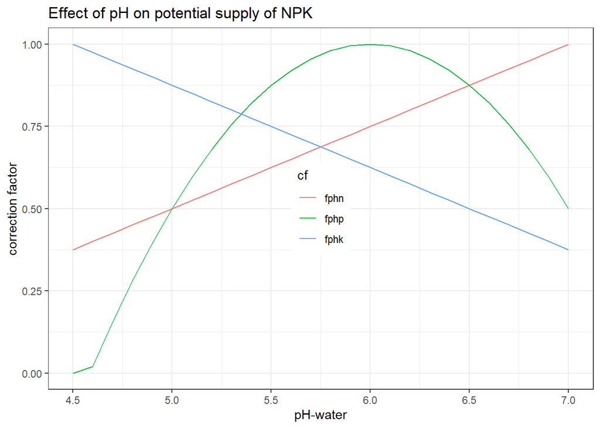

```r
  # estimate pH correction factors, so that within 0-1 range (Janssen, 1998)
  dt[,fphn := pmin(1,pmax(0,0.25 * (phw - 3)))]
  dt[,fphp := pmin(1,pmax(0,1 - 0.5 * (phw-6)^2))]
  dt[,fphk := pmin(1,pmax(0,0.625 * (3.4 - 0.4 * phw)))]


  # to illustrate the response of pH on the supply of the nutrients, we make a test example where we apply those equatiosn
  dt.plot <- data.table(phw = seq(4.5,7,0.1))
  dt.plot[,fphn := pmin(1,pmax(0,0.25 * (phw - 3)))]
  dt.plot[,fphp := pmin(1,pmax(0,1 - 0.5 * (phw-6)^2))]
  dt.plot[,fphk := pmin(1,pmax(0,0.625 * (3.4 - 0.4 * phw)))]

  # melt the table to allow easy plotting
  dt.plot <- melt(dt.plot,id.vars='phw',variable.name = 'cf')

  # plot the relationships
  p1 <- ggplot(data = dt.plot,aes(x=phw,y=value,colour = cf)) +
        geom_line() + theme_bw() + theme(legend.position = 'inside') +
        xlab('pH-water') + ylab('correction factor')+
        ggtitle('Effect of pH on potential supply of NPK')
  p1
```

```r
  # estimate the soil nutrient supply
  dt[, sn := fphn * 6.8 * soc]
  dt[, sp := fphp * 0.35 * soc + 0.5 * pols]
  dt[, sk := fphk * 400 * kexch / (2 + 0.9 * soc)]

  # print how much NPK is supplied
  print(paste0('the soil N supply is estimated at', round(dt$sn),' kg N/ha.'))
```

```
## [1] "the soil N supply is estimated at137 kg N/ha."
```

```r
  print(paste0('the soil P supply is estimated at', round(dt$sp),' kg P/ha.'))
```

```
## [1] "the soil P supply is estimated at17 kg P/ha."
```

```r
  print(paste0('the soil K supply is estimated at', round(dt$sk),' kg K/ha.'))
```

```
## [1] "the soil K supply is estimated at239 kg K/ha."
```

## Step 2. Calculate the potential supply and actual uptake

The relationships between the potential supply and the actual uptake of a nutrient were based on the following considerations. The nutrients are first compared in pairs. Thus, the relation between the actual uptake and the potential supply of nitrogen is calculated twice: as depending on the potential supply of phosphorus and as depending on the potential supply of potassium. Likewise, the actual uptake of phosphorus is calculated as depending on the potential supplies of nitrogen and potassium, and that of potassium as depending on the potential supplies of nitrogen and phosphorus. This results in two estimates of the actual uptake for each of the three nutrients. The lower of the two estimates is considered the more realistic, in conformity with the law of the minimum.

In QUEFTS the crop uptake is driven by four crop parameters: a, d, r and maximum yield. These are defined as follows: • The so-called `d` parameter represents the slope of the relationship between marketable yield (e.g., grain) as a function of total (grain + straw) crop nutrient uptake where the nutrient is maximally diluted in the plant. It is expressed in kg yield dry matter (per ha) divided by kg total uptake of the nutrient (per ha) (kg / kg). • The so-called `a` parameter represents the slope of the relationship between marketable yield (e.g., grain) as a function of total (grain + straw) crop nutrient uptake where the nutrient is maximally accumulated in the plant. It is expressed in kg yield dry matter (per ha) divided by kg total uptake of the nutrient (per ha) (kg / kg). • The minimum or residual nutrient uptake required to produce any marketable yield is the `r` parameter. It is expressed in kg total uptake of the nutrient per ha (kg / ha). Often this value is small, or even neglected (i.e., r = 0). • The parameters `a`, `d` and `r` must be known for each nutrient (e.g., N, P, K). In addition, QUEFTS makes use of a maximum possible yield, which is only used to prevent unrealistic high predictions. This maximum yield can be seen as a physiological maximum possible yield.

In QUEFTS, the interaction between any pair of nutrients is taken into account when calculating the actual uptake of nutrients. For each nutrient several estimates of U are obtained, for which the minimum value will be used in the remainder of the calculations (cf. Liebig’s law of the minimum).

```r
  # get quefts coefficients for a maize crop
  parms_quefts <- data.table(aN = 34,aP = 190,aK = 38,
                             dN = 77,dP = 613,dK = 175,
                             rN = 5,rP = 0.4,rK = 2,
                             CN = 111,CP = 803,CK = 213,
                             sN = 1,sP = 1,sK = 1)

  # which nutrients are used
  nuts=c('N','P','K')

  # make a data.table with all combinations to assess the interaciton effects of any pair of nutrients
  # add column names for nutrient 1 (n1) and nutrient 2 (n2)
  o1 <- utils::combn(nuts, 2)
  o1 <- as.data.table(t(cbind(o1, o1[c(2,1),])), stringsAsFactors = FALSE)
  colnames(o1) <- c('n1', 'n2')

  # add QUEFTS properties to data.table for each pair of nutrients
  o1[, a1 := as.numeric(parms_quefts[,mget(paste0('a',n1))])]
  o1[, d1 := as.numeric(parms_quefts[,mget(paste0('d',n1))])]
  o1[, r1 := as.numeric(parms_quefts[,mget(paste0('r',n1))])]
  o1[, a2 := as.numeric(parms_quefts[,mget(paste0('a',n2))])]
  o1[, d2 := as.numeric(parms_quefts[,mget(paste0('d',n2))])]
  o1[, r2 := as.numeric(parms_quefts[,mget(paste0('r',n2))])]

  # set an unique ID per combination of inputs (soil and fertilizer supply)
  dt[,id:=.I]

  # calculate the total nutrient input (in kg/ha)
  dt[, N := sn + nfert]
  dt[, P := sp + pfert]
  dt[, K := sk + kfert]

  # reformat the input table
  dt <- melt(dt,
             id.vars='id',
             measure.vars=nuts,
             variable.name='n1',
             value.name='s1')

  # enumerate quefts parameter set with all 2-way interactions for each site
  o2 = o1[rep(1:nrow(o1),nrow(dt)),]
  o2[,id := sort(rep(min(dt$id):max(dt$id),3 * nrow(o1)))]
  setkey(o2,id,n1,n2)
  setkey(dt,id,n1)

  # left_join with element n1 and n2 to ensure that all QUEFTS parameters are connected to each pair of nutrients
  o2[dt,on=.(id,n1),s2:=s1]
  o2=o2[dt,on=c(id='id',n2='n1'),nomatch=0L]
  setnames(o2,names(o2),c(names(o2)[1:9],'s1','s2'))

  # First define a helper function to estimate the nutrient uptake given the interactions between nutrient 1 and nutrient 2
  qnup = function(a1,d1,r1,s1,a2,d2,r2,s2){

    ou = pmax(ifelse(s1 < r1 + (s2 - r2)*a2/d1,  s1,
                     ifelse(s1 > r1 + (s2 - r2)*(2*(d2/a1) - a2/d1), r1 + (s2 - r2)*(d2/a1),
                            s1 - ((0.25*(s1 - r1 - (s2 - r2)*(a2/d1))^2)/((s2 - r2)*(d2/a1 - a2/d1))))),0)
         return(ou)}


  # calculate for each soil the uptake for combinations of nutrients
  o2[, uptake := qnup(a1,d1,r1,s1+0.001,a2,d2,r2,s2+0.001)]

  # calculate the minimum of two-pair interactions
  o2[,upt1 := min(uptake),by=list(id,n1)]

  # add minimum yield corresponding to second nutrient (necessary for calculation YA and YD later)
  o2[o2[,c('id','n1','upt1')],on=c(id='id',n2='n1'),upt2 := i.upt1]
  up = dcast(o2,id~n1,value.var='upt1',fun.aggregate=mean)

  # show the minimum yield based on the availability of nutrient
  print(up)
```

```
## Key: <id>
##       id        K        N        P
##    <int>    <num>    <num>    <num>
## 1:     1 236.5636 189.0559 38.07726
```

## Step 3. Calcualting actual uptake and yield ranges

```r
  # first define a helper function to quantify the yield (kg/ha) at accumulation (YA.) and dilution (YD.) per nutrient
  # inputs include the nutrient name for each pair (n1 and n2), the uptake for nutrient 2 and nutrient 1, and the quefts crop parameters (qp)
  qYAYD <- function(n1,n2,upt2,upt1,qp=inpc){

    inpc = NULL

    # select only relevant quefts parameters
    qp = unlist(qp[,grepl('^a|^d|^r',colnames(qp))])

    # calculate yields at acummulation (YA) and dilution (YD) per nutrient
    YA = qp[paste0('a',n2)] * pmax(upt2 - qp[paste0('r',n2)],0)
    YD = qp[paste0('d',n2)] * pmax(upt2 - qp[paste0('r',n2)],0)
    a1 = qp[paste0('a',n1)]
    d1 = qp[paste0('d',n1)]
    r1 = qp[paste0('r',n1)]

    # calculate maximum yields
    YL = qp[paste0('d',n1)] * pmax(upt1 - qp[paste0('r',n1)],0)

    # combine output and return
    ou = list(YA=YA,YD=YD,YL=YL,a1=a1,d1=d1,r1=r1)
    return(ou)
  }

  # helper function 2: calculate the yield per pair of nutrients
  qYpNpair <- function(upt1,YD,YA,a1,d1,r1,YL){

    # select only relevant quefts parameters
    yield = pmin(YL,ifelse(YA > 0, YA + (2*(YD - YA)* (upt1 - r1 - YA/d1))/(YD/a1 - YA/d1) -
                             ((YD - YA)*(upt1 - r1 - YA/d1)^2)/((YD/a1 - YA/d1)^2), 0))

            return(yield)
    }

  # calculate yields at accumulation (YA.) and dilution (YD.) per nutrient
  o2[,c('YA','YD','YL','a1','d1','r1'):= qYAYD(n1,n2,upt2,upt1,qp=as.data.frame(parms_quefts))]

  # set internal table with maximal yields per field
  dt.ym <- data.table(id = 1:arg.length,YM = max_yield)

  # merge table with maximal yields per field
  o2 <- merge(o2,dt.ym, by = 'id')

  # calculate maximum yield, and yield per pair of nutrients
  # where yield can not exceed the maximum
  o2[,c('YL'):= list(round(min(YL,YM))),by=id][,c('yield'):=list(qYpNpair(upt1,YD,YA,a1,d1,r1,YL))]

  # print the yield and uptake for one option as example
  print(o2[1,.(id,n1,n2,uptake,yield,YA,YD,YM)])
```

```
## Key: <id>
##       id     n1     n2   uptake    yield       YA       YD    YM
##    <int> <char> <char>    <num>    <num>    <num>    <num> <num>
## 1:     1      K      N 236.5636 12839.17 6257.902 14172.31 16000
```

## Step 4. Combining yield ranges to one yield estimate

The ultimate yield estimate (YE) is obtained by averaging all yields for paired nutrients. An important condition should be fulfilled, however, in that the yield calculated for any combination of two nutrients may not exceed the upper limit of the yield range of the third nutrient or any other yield limit that might result from other growth factors.

```r
  # the final yield the average of all pair-estimates
  y1 <- o2[,list(yield=mean(yield,na.rm=TRUE)),by=id]

  # merge the predicted yield with the predicted nutrient uptake, and update the names
  y1 <- y1[up,on='id']
  setnames(y1,names(y1),ifelse(names(y1) %in% nuts,paste0('u',names(y1)),names(y1)))

  # print the yield and uptake
  print(y1)
```

```
## Key: <id>
##       id    yield       uK       uN       uP
##    <int>    <num>    <num>    <num>    <num>
## 1:     1 12881.42 236.5636 189.0559 38.07726
```

## the full QUEFTS function

Below the full calculation is combined into one function called `s2p_calc_quefts`.

```r
#' The QUEFTS model
#'
#' This function contains the QUEFTS model for NPK
#'
#' @param nin (numeric) the effective nitrogen input (kg N/ha) from soil and fertilizer
#' @param pin (numeric) the effective phosphorus input (kg P/ha) from soil and fertilizer
#' @param kin (numeric) the effective potassium input (kg K/ha) from soil and fertilizer
#' @param soc (numeric) the soil organic carbon content (g / kg)
#' @param pol (numeric) the Olsen-P content (mg P/kg)
#' @param phw (numeric) the soil pH measured in water
#' @param kexch (numeric) the exchangeable potassium content (mmol / kg)
#' @param max_yield (integer) the maximal attainable yield (kg / ha)
#'
#'@export
s2p_calc_quefts <- function(nin,pin,kin, soc, pol, phw,kexch, max_yield){

  # Visual bindings
  a1 = n1 = d1 = r1 = s1 = a2 = n2 = d2 = r2 = s2 = id = uptake = upt1 = upt2 = i.upt1 = YL = YD = YA = YM = yield = . = NULL

  # check input lenght
  arg.length <- max(length(nin),length(pin),length(kin),length(soc),length(pol),length(kexch),length(phw))

  # check input
  checkmate::assert_numeric(nin,lower=0,upper = 500,len = arg.length)
  checkmate::assert_numeric(pin,lower=0,upper = 500,len = arg.length)
  checkmate::assert_numeric(kin,lower=0,upper = 800,len = arg.length)
  checkmate::assert_numeric(pol,lower=0,upper = 100,len = arg.length)
  checkmate::assert_numeric(soc,lower=0,upper = 200,len = arg.length)
  checkmate::assert_numeric(phw,lower=3,upper = 8,len = arg.length)
  checkmate::assert_numeric(kexch,lower=0,upper = 150,len = arg.length)

  # which QUEFTS nutrients are used as input
  nuts=c('N','P','K')

  # all combinations
  o1 <- utils::combn(nuts, 2)
  o1 <- as.data.table(t(cbind(o1, o1[c(2,1),])), stringsAsFactors = FALSE)
  colnames(o1) <- c('n1', 'n2')

  # Select quefts parameters for crop and management level
  parms_quefts <- data.table(aN = 34,aP = 190,aK = 38,
                             dN = 77,dP = 613,dK = 175,
                             rN = 5,rP = 0.4,rK = 2,
                             CN = 111,CP = 803,CK = 213,
                             sN = 1,sP = 1,sK = 1)

  # add QUEFTS properties to data.table
  o1[, a1 := as.numeric(parms_quefts[,mget(paste0('a',n1))])]
  o1[, d1 := as.numeric(parms_quefts[,mget(paste0('d',n1))])]
  o1[, r1 := as.numeric(parms_quefts[,mget(paste0('r',n1))])]
  o1[, a2 := as.numeric(parms_quefts[,mget(paste0('a',n2))])]
  o1[, d2 := as.numeric(parms_quefts[,mget(paste0('d',n2))])]
  o1[, r2 := as.numeric(parms_quefts[,mget(paste0('r',n2))])]

  # estimate total nutrient inputs from fertilizer and soil supply of nutrients (in kg / ha)
  dt0 <- data.table(soc = soc,pols = pol,kexch = kexch, phw = phw,
                    N = nin,P = pin,K = kin)

    # estimate pH correction factors, so that within 0-1 range (Janssen, 1998)
    dt0[,fphn := pmin(1,pmax(0,0.25 * (phw - 3)))]
    dt0[,fphp := pmin(1,pmax(0,1 - 0.5 * (phw-6)^2))]
    dt0[,fphk := pmin(1,pmax(0,0.625 * (3.4 - 0.4 * phw)))]

    # estimate the soil nutrient supply
    dt0[, sn := fphn * 6.8 * soc]
    dt0[, sp := fphp * 0.35 * soc + 0.5 * pols]
    dt0[, sk := fphk * 400 * kexch / (2 + 0.9 * soc)]

    # calculate the total nutrient input (in kg/ha)
    dt0[, N := sn + N]
    dt0[, P := sp + P]
    dt0[, K := sk + K]

  # set an unique ID per combination of inputs
  dt0[,id:=.I]

  # set internal table with maximal yields per field
  dt.ym <- data.table(id = unique(dt0$id),YM = max_yield)

  # spread the data.table with input data for joining purposes later
  dt <- melt(dt0,
             id.vars='id',
             measure.vars=nuts,
             variable.name='n1',
             value.name='s1')

  # enumerate quefts parameter set with all 2-way interactions for each grid cel
  o2 = o1[rep(1:nrow(o1),nrow(dt)),]
  o2[,id := sort(rep(min(dt$id):max(dt$id),3 * nrow(o1)))]
  setkey(o2,id,n1,n2)
  setkey(dt,id,n1)

  # left_join with element n1 and n2
  o2[dt,on=.(id,n1),s2:=s1]
  o2=o2[dt,on=c(id='id',n2='n1'),nomatch=0L]
  setnames(o2,names(o2),c(names(o2)[1:9],'s1','s2'))

  # calculate for each soil the uptake for combinations of nutrients, and then the minimum of two-pair interactions
  o2[, uptake := qnup(a1,d1,r1,s1+0.001,a2,d2,r2,s2+0.001)][,upt1 := min(uptake),by=list(id,n1)]

  # add minimum yield corresponding to second nutrient (necessary for calculation YA and YD later)
  o2[o2[,c('id','n1','upt1')],on=c(id='id',n2='n1'),upt2 := i.upt1]
  up = dcast(o2,id~n1,value.var='upt1',fun.aggregate=mean)

  # calculate yields at accumulation (YA.) and dilution (YD.) per nutrient (DELAYING)
  o2[,c('YA','YD','YL','a1','d1','r1'):= qYAYD(n1,n2,upt2,upt1,qp=as.data.frame(parms_quefts))]

  # merge table with maximal yields per field
  o2 <- merge(o2,dt.ym, by = 'id',all.x = TRUE)

  # calculate maximum yield, and yield per pair of nutrients
  o2[,c('YL'):= list(round(min(YL,YM))),by=id][,c('yield'):=list(qYpNpair(upt1,YD,YA,a1,d1,r1,YL))]

  # y1 equals the average of all pair-estimates
  y1 <- o2[,list(yield=mean(yield,na.rm=TRUE)),by=id]

  # merge with the estimated nutrient uptake
  y1 <- y1[up,on='id']
  setnames(y1,names(y1),ifelse(names(y1) %in% nuts,paste0('u',names(y1)),names(y1)))

  # add the given input dose
  y1 = y1[dt0,on='id']

  return(y1)
}
```

## illustration of the full QUEFTS crop prediciton function

Below we illustrate an example how QUEFTS function can be used. This is done for a single test case with one soil and one fertilizer practice (fixed N, P and K dose). Second, we illustrate this for a single soil with various N inputs and a fixed P and K input.

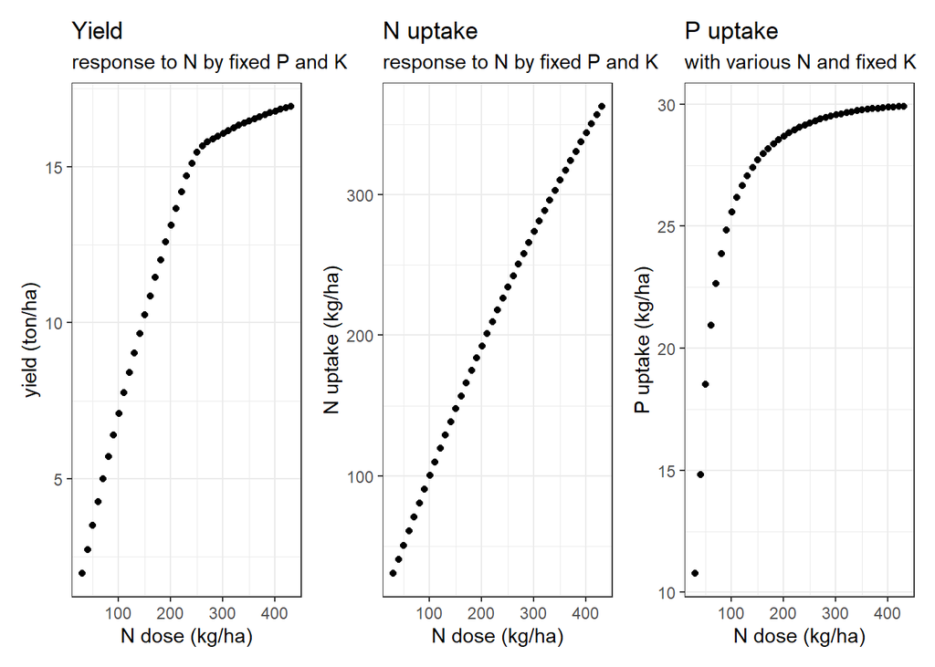

```r
  # test the function for one soil
  test = s2p_calc_quefts(nin = 100,pin = 25,kin = 85, soc = 15, pol = 35, phw = 4.9,kexch = 45, max_yield = 20000)

  # test the function for one soil with varying N inputs
  dt.test <- data.table(id = 1,
                        soc = 10,
                        pol = 8,
                        kexch = 14,
                        phw = 4.8,
                        nfert = seq(0,400,10),
                        pfert = 25,
                        kfert = 105)

  # run test 2
  test2 <- s2p_calc_quefts(nin = dt.test$nfert,
                           pin = dt.test$pfert,
                           kin = dt.test$kfert,
                           soc = dt.test$soc,
                           pol = dt.test$pol,
                           phw = dt.test$phw,
                           kexch = dt.test$kexch,
                           max_yield = 20000)

  # plot the yield
  p1 <- ggplot(data=test2,aes(y=yield*0.001,x=N)) + geom_point()+ theme_bw() +
        ggtitle(label = 'Yield',subtitle = 'response to N by fixed P and K') +
        xlab('N dose (kg/ha)') + ylab('yield (ton/ha)')

  # plot the nutrient uptake
  p2 <- ggplot(data=test2,aes(y=uN,x=N)) + geom_point()+ theme_bw() +
        ggtitle(label = 'N uptake', subtitle = 'response to N by fixed P and K') +
        xlab('N dose (kg/ha)') + ylab('N uptake (kg/ha)')
  p3 <- ggplot(data=test2,aes(y=uP,x=N)) + geom_point()+ theme_bw() +
        ggtitle(label = 'P uptake',subtitle = 'with various N and fixed K') +
        xlab('N dose (kg/ha)') + ylab('P uptake (kg/ha)')

  # combine plots
  p4 <- p1 + p2 + p3

  # show plot
  print(p4)
```